# R Notebook

The dataset for HW 6 is the same as previous. The four features we are interested in are radius_mean, texture_mean, smoothness_mean, compactness_mean.  
1. Remove 20% of your data and save it as test_set and the other 80% as training_set. a. Make sure your datasets will have the same ratio of Benign and Malignant.

```r
read.csv("data.csv", header=T, row.names=1)->cancer_data # reading the file and calling it cancer_data.

cancer_data[c("diagnosis","radius_mean", "texture_mean", "smoothness_mean", "compactness_mean")] -> cancer_df
head(cancer_df)
```

|  | diagnosis | radius_mean | texture_mean | smoothness_mean | compactness_mean |
| --- | --- | --- | --- | --- | --- |
| 842302 | M | 17.99 | 10.38 | 0.11840 | 0.27760 |
| 842517 | M | 20.57 | 17.77 | 0.08474 | 0.07864 |
| 84300903 | M | 19.69 | 21.25 | 0.10960 | 0.15990 |
| 84348301 | M | 11.42 | 20.38 | 0.14250 | 0.28390 |
| 84358402 | M | 20.29 | 14.34 | 0.10030 | 0.13280 |
| 843786 | M | 12.45 | 15.70 | 0.12780 | 0.17000 |

```r
table(cancer_df$diagnosis)
```

```
##
##   B   M
## 357 212
```

```r
# Balancing the dataset to make sure your test_set and training_set datasets will have the same proportion of Benign and Malignant.

Benign<-cancer_df[which(cancer_df[,"diagnosis"] == "B"),]
Malignant<-cancer_df[which(cancer_df[,"diagnosis"] == "M"),]
sample(1:nrow(Benign), nrow(Malignant))->rand.0
Benign[rand.0,]->BT
Malignant->MT
```

```r
table(BT[, "diagnosis"])
```

```
##
##   B   M
## 212   0
```

```r
table(MT[, "diagnosis"])
```

```
##
##   B   M
##   0 212
```

```r
# Splitting the data into training and test set
set.seed(900)
training.split<-rbind(BT, MT)
split<-sample(nrow(training.split), floor(nrow(training.split) * 0.8)) # Storing 80% data as training set
split.train<-training.split[split,]
split.test<-training.split[-split,]
```

```r
table(split.train[, "diagnosis"])
```

```
##
##   B   M
## 170 169
```

Part 1: SVM Build a predictive model with SVM using the training_set with the four different variables listed above. a. Try using different values for c.Which c gives the best performance?

#ANSWER: c = 0.1 gives the best performance

```r
library(e1071)
library(AUC)
```

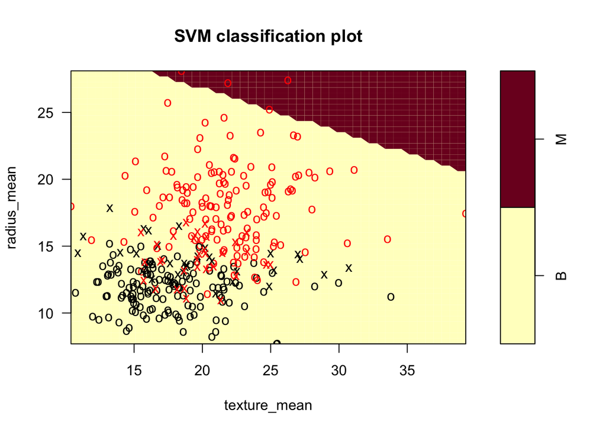

```r
#Build an SVM model.
model_svm <- svm(diagnosis ~ radius_mean + texture_mean + smoothness_mean + compactness_mean,
            data = split.train,cost=10,kernel="linear",probability=T)
plot(model_svm, split.train, radius_mean ~ texture_mean)
```

```r
#  We’ll vary the cost from 0.1 to 30 by increment of 0.1.
set.seed(100)
svm_tune <- tune(svm, diagnosis ~ radius_mean + texture_mean + smoothness_mean + compactness_mean,data = split.train,kernel="linear",probability=T,
            ranges = list(cost = seq(0.1, 30, 0.1))
)
print(svm_tune)
```

```
##
## Parameter tuning of 'svm':
##
## - sampling method: 10-fold cross validation
##
## - best parameters:
##  cost
##   0.1
##
## - best performance: 0.06773619
```

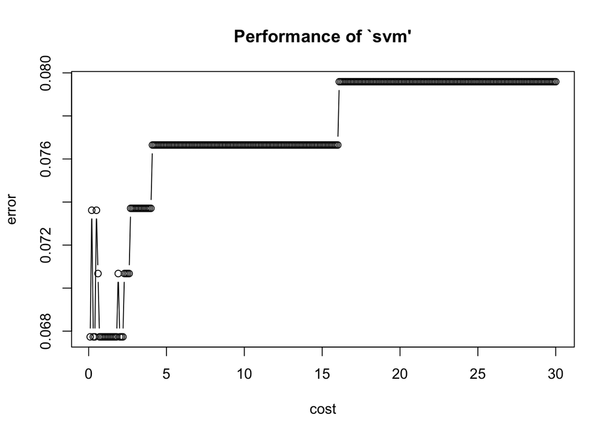

```r
plot(svm_tune)
```

```r
svm_tune$best.model
```

```
##
## Call:
## best.tune(method = svm, train.x = diagnosis ~ radius_mean + texture_mean +
##     smoothness_mean + compactness_mean, data = split.train, ranges = list(cost = seq(0.1,
##     30, 0.1)), kernel = "linear", probability = T)
##
##
## Parameters:
##    SVM-Type:  C-classification
##  SVM-Kernel:  linear
##        cost:  0.1
##
## Number of Support Vectors:  105
```

2. Use test_set to calculate the AUC of the best model created using the training_set.

```r
best.svm = svm(diagnosis ~ radius_mean + texture_mean + smoothness_mean + compactness_mean,
            data = split.train, kernel="linear", cost=0.1,
            probability=T)

# Using the test set to calculate the AUC of the best model
best.svm.pred.prob = predict(best.svm, newdata = split.test, probability=T)
table(best.svm.pred.prob,split.test$diagnosis)
```

```
##
## best.svm.pred.prob  B  M
##                  B 40  3
##                  M  2 40
```

```r
best.svm.pred.prob.mat = attr(best.svm.pred.prob, "probabilities")
bestsvmroc = roc(predictions = best.svm.pred.prob.mat[,2], split.test$diagnosis)
auc(bestsvmroc)
```

```
## [1] 0.9795127
```

Part 2. Neuralnet Build a predictive model with Neuralnet to classify the test_set based on the values from training_set. a. Try different size of hidden layers, ( 1, 10, 20). Calculate the AUC of the Neuralnet models to determine which gives the best result?

```r
library(neuralnet)
library(e1071)

# Scaling the data

maxs<-apply(cancer_df[,2:5], 2, max)
mins<-apply(cancer_df[,2:5], 2, min)

scaled.data<-as.data.frame(scale(cancer_df[,2:5],center=mins,scale = maxs-mins))

diagnosis<-as.numeric(cancer_df$diagnosis)-1

scaled.data.df<-cbind(diagnosis,scaled.data)

set.seed(70)
table(scaled.data.df[,"diagnosis"])
```

```
##
##   0   1
## 357 212
```

```r
#Balancing the dataset ;B = 0, M = 1
allM<-scaled.data.df[which(scaled.data.df[,"diagnosis"] == 1),]
allB<-scaled.data.df[which(scaled.data.df[,"diagnosis"] == 0),]

rand.0 <- sample(1:nrow(allB), nrow(allM))
Benign_Data <- allB[rand.0,]
Malignant_Data <- allM

#Splitting the scaled data into training and test set
training_split<-rbind(Benign_Data, Malignant_Data)
split1<-sample(nrow(training_split), floor(nrow(training_split) * 0.8))
data.train<-training_split[split1,]
data.test<-training_split[-split1,]
```

```r
table(data.train[,"diagnosis"])
```

```
##
##   0   1
## 172 167
```

```r
table(data.test[,"diagnosis"])
```

```
##
##  0  1
## 40 45
```

```r
# Trying different size of hidden layers, hidden=c(1)
data.nn.1 = neuralnet(diagnosis ~ radius_mean + texture_mean + smoothness_mean + compactness_mean,
            data = data.train,
                    hidden=c(1), rep=1, linear.output = F)
plot(data.nn.1)
```

```r
#Calculating the AUC value of the Neuralnet model
data.nn.1results = compute(data.nn.1, data.test[,2:5])

data.nn.1roc = roc(data.nn.1results$net.result,
                  as.factor(data.test$diagnosis))
auc(data.nn.1roc)
```

```
## [1] 0.9838889
```

```r
# Trying different size of hidden layers, hidden=c(10)

data.nn.10 = neuralnet(diagnosis ~ radius_mean + texture_mean + smoothness_mean + compactness_mean,
            data = data.train,
                    hidden=c(10), rep=1, linear.output = F)

plot(data.nn.10)
```

```r
#Calculating the AUC value of the Neuralnet model
data.nn.10results = compute(data.nn.10, data.test[,2:5])

data.nn.10roc = roc(data.nn.10results$net.result,
                  as.factor(data.test$diagnosis))
auc(data.nn.10roc)
```

```
## [1] 0.9905556
```

```r
# Trying different size of hidden layers, hidden=c(20)
data.nn.20 = neuralnet(diagnosis ~ radius_mean + texture_mean + smoothness_mean + compactness_mean,
            data = data.train,
                    hidden=c(20), rep=1, linear.output = F)

plot(data.nn.20)
```

```r
#Calculating the AUC value of the Neuralnet model
data.nn.20results = compute(data.nn.20, data.test[,2:5])

data.nn.20roc = roc(data.nn.20results$net.result,
                  as.factor(data.test$diagnosis))
auc(data.nn.20roc)
```

```
## [1] 0.9872222
```

# The Neuralnet models where we set the hidden layer = 10 gives the best result